# 80’s vs Trance: An Analytical Comparison

Joy Crosbie

9-2-2021

## R Markdown

My corpus consists of a playlist containing 80’s new wave/new romantic songs and a playlist containing trance classics from the early 90’s to the mid 2010’s. I was inspired by a statement made by BBC Radio 2, referring to Blue Monday (New Order’s 1983 hit), as “a crucial link between Seventies disco and the dance/house boom that took off at the end of the Eighties.” The repetative use of synths and heavy drum beats is a known characteristic of both new wave and trance music, and lead me to compare the two and see if any links could indeed be found.

Although the synthesizer is common in both playlists, there are some obvious differences when it comes to the tones. The ‘punchy’ synth sounds from the 80’s have become more complex chord progressions of sweeping strings in trance music. I believe this will also be apparent in the valence and keys of the compared genres, because of the dark influences of the new-romantic style and the socially critical new-wave style compared to the euphoric feeling of trance music. Interestingly, the number of female voices in the trance songs is significantly larger than the number of male voices, which is less apparent in the 80’s genres. Moreover, the number of instrumental tracks is notably larger in the trance playlist. I am curious to see the difference in the ‘energy’ measured by spotify, as I believe both genres contain a high amount of energy, but the energy they contain is different, as described above.

Typical examples of interesting tracks from the 80’s playlist would be Blue Monday - New Order and Fade To Grey - Visage. Both tracks contain a basic chord progression in a minor key played on a synthesizer repeated throughout the song, accompanied by a similar drum and high hat beat. Typical examples of interesting tracks from the trance playlist would be Adagio for Strings - Tiësto and Carte Blanche - Veracocha. Both songs contain well known riffs and are comprised of a musical form that distinctly builds tension to either end in “peaks” or “drops”. Both songs are also in minor keys, a common characteristic of trance music.

New wave/romantic playlist: The 80’s all lined up Trance: Old trance classics

## Plots

```r
library(tidyverse)
library(spotifyr)
```

```r
eighties <- get_playlist_audio_features("", "7E2Eignrw84V9pBzNoWpd9")
eightiessummary <- eighties %>%
  summarise(
    mean_speechiness = mean(speechiness),
    mean_acousticness = mean(acousticness),
    mean_liveness = mean(liveness),
    mean_danceability = mean(danceability),
    mean_valence = mean(valence),
    mean_energy = mean(energy),
    mean_key = mean(key),
    mean_loudness = mean(loudness),
    mean(valence),
    sd_speechiness = sd(speechiness),
    sd_acousticness = sd(acousticness),
    sd_liveness = sd(liveness),
    median_speechiness = median(speechiness),
    median_acousticness = median(acousticness),
    median_liveness = median(liveness),
    mad_speechiness = mad(speechiness),
    mad_acousticness = mad(acousticness),
    mad_liveness = mad(liveness)
  )
```

```r
trance <- get_playlist_audio_features("", "3XKJmcxhdP8NXIoamf5zwc")
trancesummary <- trance %>%
  summarise(
    mean_speechiness = mean(speechiness),
    mean_acousticness = mean(acousticness),
    mean_liveness = mean(liveness),
    mean_danceability = mean(danceability),
    mean_valence = mean(valence),
    mean_energy = mean(energy),
    mean_key = mean(key),
    mean_loudness = mean(loudness),
    mean(valence),
    sd_speechiness = sd(speechiness),
    sd_acousticness = sd(acousticness),
    sd_liveness = sd(liveness),
    median_speechiness = median(speechiness),
    median_acousticness = median(acousticness),
    median_liveness = median(liveness),
    mad_speechiness = mad(speechiness),
    mad_acousticness = mad(acousticness),
    mad_liveness = mad(liveness)
  )
```

```r
playlists <-
  bind_rows(
    eighties %>% mutate(category = "Eighties"),
    trance %>% mutate(category = "Trance")
  )
```

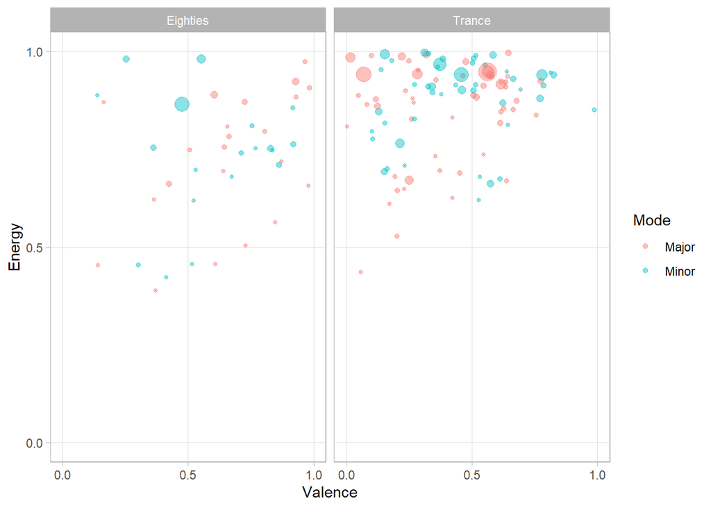

```r
playlists %>%                    # Start with awards.
  mutate(
    mode = ifelse(mode == 0, "Minor", "Major")
  ) %>%
  ggplot(                     # Set up the plot.
    aes(
      x = valence,
      y = energy,
      size = loudness,
      colour = mode
    )
  ) +
  geom_jitter(alpha = 0.45, width = 0.1) +
  facet_wrap(~ category) +
   scale_x_continuous(         # Fine-tune the x axis.
    limits = c(0, 1),
    breaks = c(0, 0.50, 1),   # Use grid-lines for quadrants only.
    minor_breaks = NULL       # Remove 'minor' grid-lines.
  ) +
  scale_y_continuous(         # Fine-tune the y axis in the same way.
    limits = c(0, 1),
    breaks = c(0, 0.50, 1),
    minor_breaks = NULL
  ) +
   scale_size_continuous(      # Fine-tune the sizes of each point.
    trans = "exp",            # Use an exp transformation to emphasize loud.
    guide = "none"            # Remove the legend for size.
  ) +
  theme_light() +             # Use a simpler theme.
  labs(                       # Make the titles nice.
    x = "Valence",
    y = "Energy",
    colour = "Mode"
  )
```